# MSBA Workshop: Brief Review of Logarithms

## Logarithms

- A **logarithm** is an exponent.
- If $y = b^x$ then $\log_b(y) = x$.
- $b$ is called the base.
- A logarithm answers the question: “Compute the power ($x$) that a base ($b$) must be raised to in order to return a certain value ($y$).”
- For example, since $16 = 4^2$ then $\log_4(16) = 2$, and since $16 = 2^4$ then $\log_{2}(16) = 4$.
1. $\log_{10}(100)$
2. $\log_{10}(1000)$
3. $\log_{10}(10000)$
4. $\log_{10}(10)$
5. $\log_{10}(1)$
6. $\log_{8}(64)$
7. $\log_{2}(64)$
- Any number to the power of 0 is 1: $b^0 = 1$.
- So $\log_b(1) = 0$ for any base $b$.

## Logarithms in Python

The libraries `math` and `numpy` include functions for computing logarithms.

```python
import math

math.log(100, 10)
```

```
2.0
```

```python
math.log(64, 8)
```

```
2.0
```

```python
math.log(64, 2)
```

```
6.0
```

## The number $e$

Invest 1 dollar at an annual interest rate of 100%. How much money do you have at the end of 1 year if interest is compounded:

1. Annually
2. Semi-annually
3. Monthly
4. Daily
5. $n$ times in the year
6. Continuously

$$e = \lim_{n\to\infty} \left(1 + \frac{1}{n}\right)^n \approx 2.7183$$

```python
import numpy as np

np.exp(1)
```

```
2.718281828459045
```

## Exponential function

How much money do you have at the end of 2 years if interest is compounded continuously?

```python
import numpy as np

np.exp(2)
```

```
7.38905609893065
```

Invest 1 dollar at an annual interest rate of 10%. How much money do you have at the end of 1 year if interest is compounded:

1. Annually
2. Semi-annually
3. Monthly
4. Daily
5. $n$ times in the year
6. Continuously

$$e^x = \lim_{n\to\infty} \left(1 + \frac{x}{n}\right)^n$$

## Natural logarithm

The base-$e$ logarithm is called the **natural logarithm**. In math, it is usually denoted $\ln$.

$$\ln(x) = \log_e(x)$$

However, in data science and in most software packages, Python included, $\log$ or `log` refers to “natural log”.

```python
np.log(np.exp(1))
```

```
1.0
```

```python
np.log(np.exp(1) ** 2)
```

```
2.0
```

```python
np.log(10)
```

```
2.302585092994046
```

The `numpy` function for base-10 logarithms is `log10`.

```python
np.log10(10)
```

```
1.0
```

```python
np.log10(100)
```

```
2.0
```

## Log Transformations

Log transformations of variables are common in data science. Let’s look at the lot area variable from the Ames housing data.

```python
import pandas as pd
```

```python
df_ames = pd.read_csv("https://raw.githubusercontent.com/kevindavisross/data301/main/data/AmesHousing.txt", sep="\t")
df_ames = df_ames.sort_values(by = "Lot Area")
df_ames
```

|  | Order | PID | MS SubClass | MS Zoning | Lot Frontage | Lot Area | Street | Alley | Lot Shape | Land Contour | ... | Pool Area | Pool QC | Fence | Misc Feature | Misc Val | Mo Sold | Yr Sold | Sale Type | Sale Condition | SalePrice |
| --- | --- | --- | --- | --- | --- | --- | --- | --- | --- | --- | --- | --- | --- | --- | --- | --- | --- | --- | --- | --- | --- |
| 935 | 936 | 909451180 | 160 | RM | 24.0 | 1300 | Pave | NaN | Reg | Lvl | ... | 0 | NaN | GdPrv | NaN | 0 | 5 | 2009 | WD | Normal | 124000 |
| 2913 | 2914 | 923226180 | 180 | RM | 21.0 | 1470 | Pave | NaN | Reg | Lvl | ... | 0 | NaN | NaN | NaN | 0 | 4 | 2006 | WD | Normal | 73000 |
| 329 | 330 | 923226250 | 160 | RM | 21.0 | 1476 | Pave | NaN | Reg | Lvl | ... | 0 | NaN | NaN | NaN | 0 | 3 | 2010 | WD | Normal | 76000 |
| 977 | 978 | 923228110 | 180 | RM | 21.0 | 1477 | Pave | NaN | Reg | Lvl | ... | 0 | NaN | NaN | NaN | 0 | 4 | 2009 | WD | Normal | 80000 |
| 1599 | 1600 | 923228080 | 160 | RM | 21.0 | 1477 | Pave | NaN | Reg | Lvl | ... | 0 | NaN | NaN | NaN | 0 | 3 | 2008 | WD | Normal | 98000 |
| ... | ... | ... | ... | ... | ... | ... | ... | ... | ... | ... | ... | ... | ... | ... | ... | ... | ... | ... | ... | ... | ... |
| 2766 | 2767 | 906475200 | 20 | RL | 62.0 | 70761 | Pave | NaN | IR1 | Low | ... | 0 | NaN | NaN | NaN | 0 | 12 | 2006 | WD | Normal | 280000 |
| 2071 | 2072 | 905301050 | 20 | RL | NaN | 115149 | Pave | NaN | IR2 | Low | ... | 0 | NaN | NaN | NaN | 0 | 6 | 2007 | WD | Normal | 302000 |
| 2115 | 2116 | 906426060 | 50 | RL | NaN | 159000 | Pave | NaN | IR2 | Low | ... | 0 | NaN | NaN | Shed | 500 | 6 | 2007 | WD | Normal | 277000 |
| 1570 | 1571 | 916125425 | 190 | RL | NaN | 164660 | Grvl | NaN | IR1 | HLS | ... | 0 | NaN | NaN | Shed | 700 | 8 | 2008 | WD | Normal | 228950 |
| 956 | 957 | 916176125 | 20 | RL | 150.0 | 215245 | Pave | NaN | IR3 | Low | ... | 0 | NaN | NaN | NaN | 0 | 6 | 2009 | WD | Normal | 375000 |

2930 rows × 82 columns

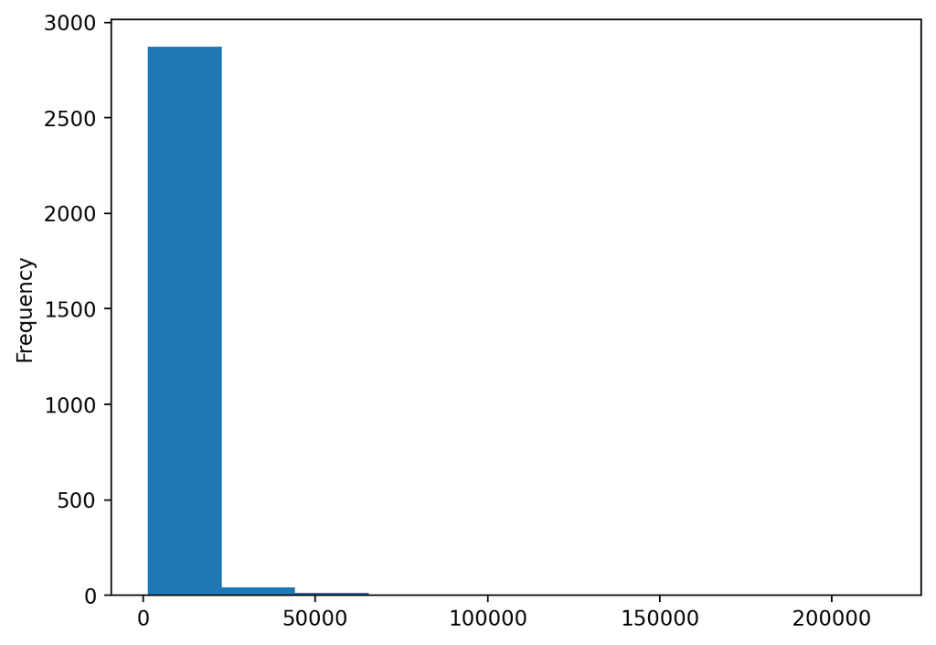

```python
df_ames["Lot Area"].plot.hist()
```

There are a few homes with such extreme lot areas that we get virtually no resolution at the lower end of the distribution. Over 95% of the observations are in a single bin of this histogram. In other words, the distribution of this variable is extremely *skewed*.

One way to improve this histogram is to use more bins. But this does not solve the fundamental problem: we need more resolution at the lower end of the scale and less resolution at the higher end. One way to spread out the values at the lower end of a distribution and to compress the values at the higher end is to take the logarithm (provided that the values are all positive). Log transformations are particularly effective at dealing with data that is skewed to the right.

```python
df_ames["log(Lot Area)"] = np.log(df_ames["Lot Area"])
df_ames[["Lot Area", "log(Lot Area)"]]
```

|  | Lot Area | log(Lot Area) |
| --- | --- | --- |
| 935 | 1300 | 7.170120 |
| 2913 | 1470 | 7.293018 |
| 329 | 1476 | 7.297091 |
| 977 | 1477 | 7.297768 |
| 1599 | 1477 | 7.297768 |
| ... | ... | ... |
| 2766 | 70761 | 11.167063 |
| 2071 | 115149 | 11.653982 |
| 2115 | 159000 | 11.976659 |
| 1570 | 164660 | 12.011638 |
| 956 | 215245 | 12.279532 |

2930 rows × 2 columns

Remember “log” usually refers to “natural log”, and that’s what we have computed (`np.log`). We could also transform using base-10 log (`np.log10`).

```python
df_ames["log10(Lot Area)"] = np.log10(df_ames["Lot Area"])
df_ames[["Lot Area", "log(Lot Area)", "log10(Lot Area)"]]
```

|  | Lot Area | log(Lot Area) | log10(Lot Area) |
| --- | --- | --- | --- |
| 935 | 1300 | 7.170120 | 3.113943 |
| 2913 | 1470 | 7.293018 | 3.167317 |
| 329 | 1476 | 7.297091 | 3.169086 |
| 977 | 1477 | 7.297768 | 3.169380 |
| 1599 | 1477 | 7.297768 | 3.169380 |
| ... | ... | ... | ... |
| 2766 | 70761 | 11.167063 | 4.849794 |
| 2071 | 115149 | 11.653982 | 5.061260 |
| 2115 | 159000 | 11.976659 | 5.201397 |
| 1570 | 164660 | 12.011638 | 5.216588 |
| 956 | 215245 | 12.279532 | 5.332933 |

2930 rows × 3 columns

These numbers are not very interpretable on their own, but if we make a histogram of these values, we see that the lower end of the distribution is now more spread out, and the extreme values are not as far out on the logarithmic scale.

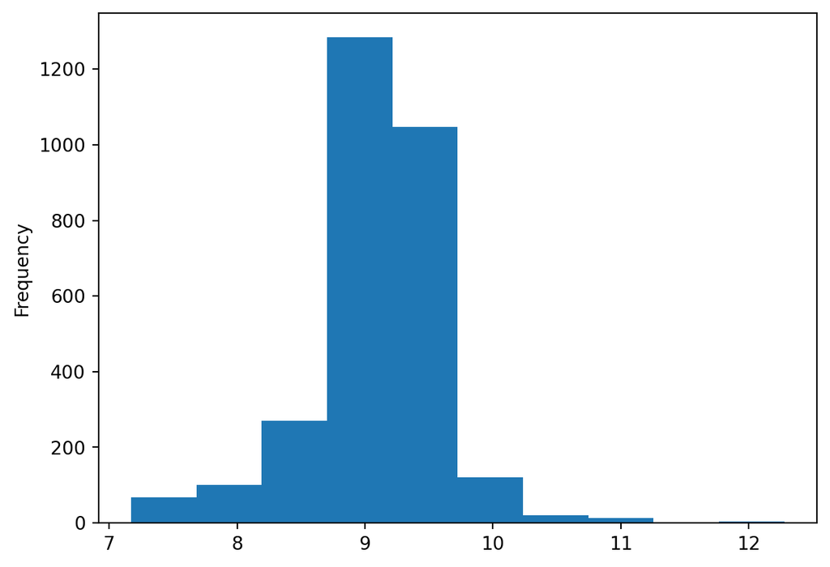

```python
df_ames["log(Lot Area)"].plot.hist()
```

The effect is the same if we take natural log or base-10 log; the only difference is the scale.

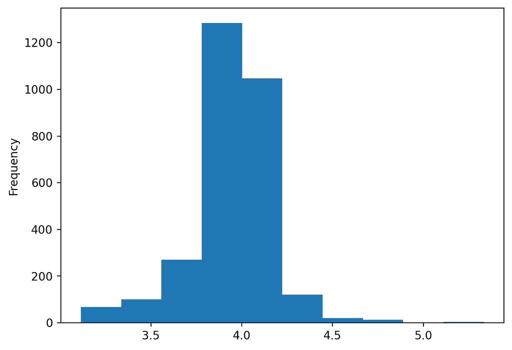

```python
df_ames["log10(Lot Area)"].plot.hist()
```

**Warning**

Do NOT interpret symmetric as “good” and skewed as “bad”. The shape of the data is what it is; there is no right or wrong.

- From an analysis perpesctive, the fact that Lot Area was skewed just meant that the histogram—which uses bins of equal width—did not adequately visualize the sample data.
- It is often more natural to view values that span multiple orders of magnitude on a logarithmic/multiplicative scale (“how many *times* bigger?”) rather than a linear/absolute scale.
- Taking a log transformation allows us to differentially zoom in to different ranges of the data, achieving better resolution when the distribution is skewed.

## Log Scale

1. How many *times* bigger is 100 than 10? Is 1000 than 10?
2. How far apart are $\log_{10}(100)$ and $\log_{10}(10)$? $\log_{10}(1000)$ and $\log_{10}(10)$?
- It is often more natural to view values that span multiple orders of magnitude on a logarithmic/multiplicative scale (“how many *times* bigger?”) rather than a linear/absolute scale (“how much bigger?”).
  - For example, if you think of a number as its leading digit followed by 0s (e.g., think of 4567 as 4000, in the thousands) then the number before the decimal point in the base-10 logarithm is the number of 0s and tells you the order of magnitude (e.g. $\log_{10}(4567) = 3.66$, so there are 3 zeros after the leading digit and 4567 is in the thousands).

  - | Base-10 log | Order of magnitude |
    | --- | --- |
    | 1.ish | Tens |
    | 2.ish | Hundreds |
    | 3.ish | Thousands |
    | 4.ish | Tens of thousands |
    | 5.ish | Hundreds of thousands |
    | 6.ish | Millions |

- A one-unit incremement in a base-$b$ log scale corresponds to a $b$ times increment in the original scale.
  - For example, each one-unit increase on a base10 log scale corresponds to a 10 times increase in the original scale
  - So on a base10 log scale, the interval 1 to 2 represents values in the tens, 2 to 3 represents hundreds, 3 to 4 reprents thousands, etc.

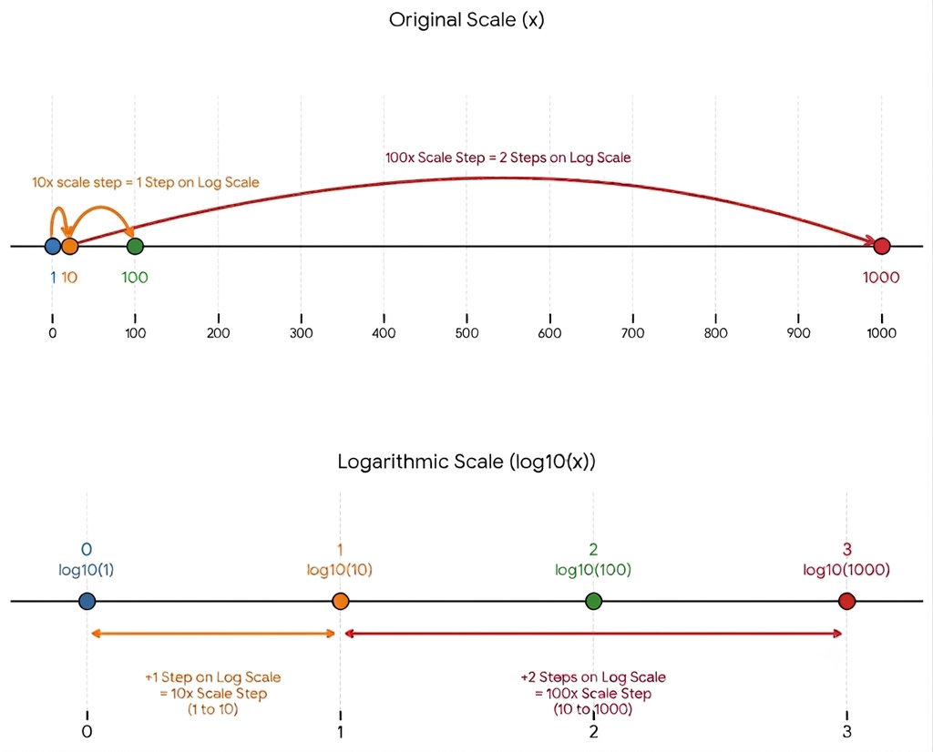

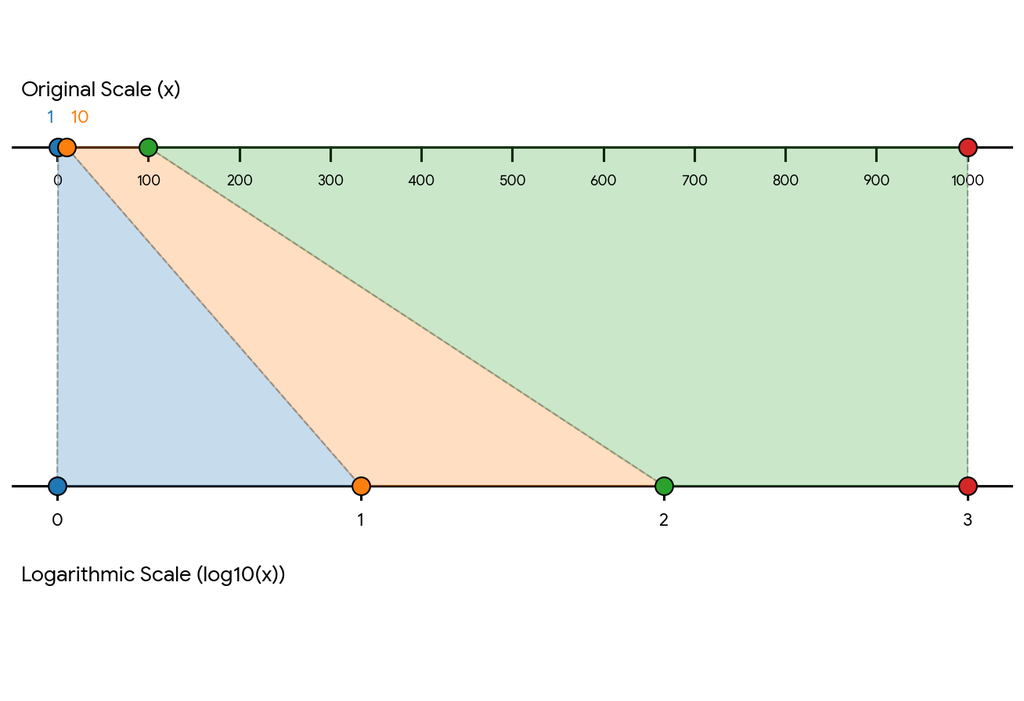

Figure 1: Illustrations of (base 10) log scale (*generated by Gemini*)

## Useful properties of logarithms

Roughly, logarithms turn multiplication into addition. The logarithm of a product is the sum of the logarithms.

$$\log_b(xy) = \log_b(x) + \log_b(y)$$

Roughly, logarithms turn exponentiation (powers) into products.
$$\log_b\left(x^y\right) = y\log_b(x)$$